# Exploring Instagram Reel Consumption Patterns

## Weekly Trends: How Reel Consumption Changes Over Time

Instagram reels have become a significant source of short-form content consumption. Understanding weekly patterns can reveal shifts in audience behavior.

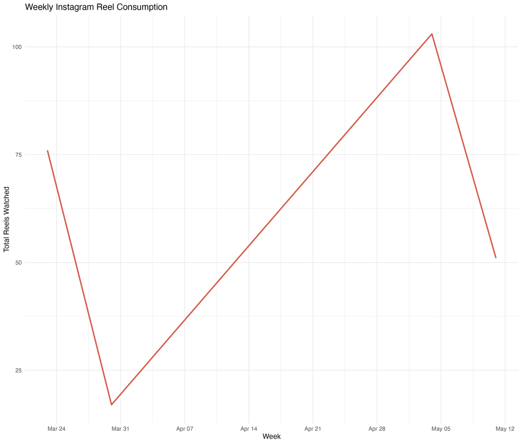

## Genre Preferences: What Are People Watching?

The genre of a reel plays a crucial role in **engagement and retention**. Let’s take a look at which categories dominate users’ interest.

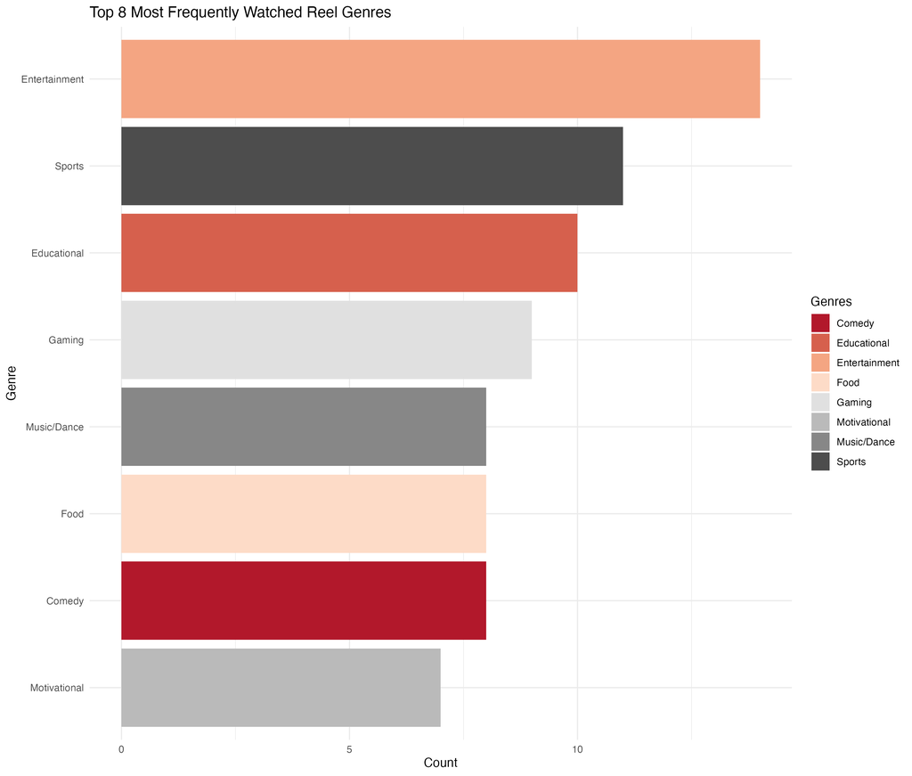

*This bar plot highlights the genres that appear most frequently in viewed reels, shedding light on my preferences when watching in my Instagram account.*

## User Engagement & Viewing Patterns: When & How People Interact

Instagram reels aren’t just passively consumed—users engage through **likes, shares, saves, and comments**. But does engagement vary by time of day?

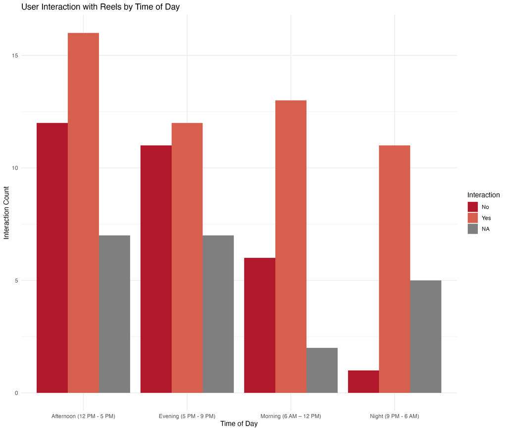

*This visualisation merges user engagement with viewing trends across different times of the day, highlighting peak interaction periods. The presence of the N/a tab imply the thought of both me adding additional questions regarding my interactions whenever I scroll in Instagram, as well painting the picture of my most active times.*

## Viewing Duration vs. Reel Count

Are **longer watching sessions** associated with **higher consumption**, or do people watch reels in short bursts? Let’s find out.

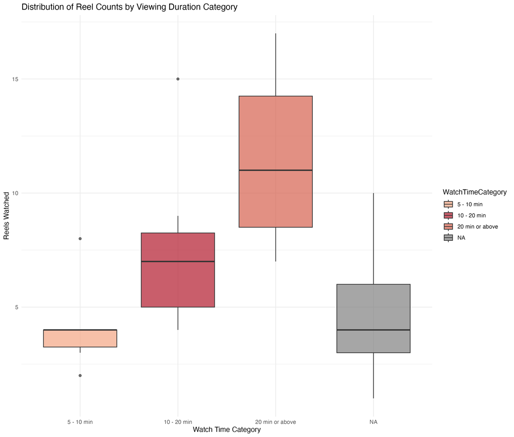

*This boxplot illustrates the relationship between time spent watching and the number of reels I have consumed at a specific amount of time.*